# Using CopyKAT to idenfity tumor cells in Ewing sarcoma samples

Ally Hawkins

2024-05-06

## Introduction

This notebook explores using [`CopyKAT`](https://github.com/navinlabcode/copykat) to estimate tumor and normal cells in SCPCS000490 from SCPCP000015.

`CopyKAT` was run using the `run-copykat.R` script and specifying endothelial cells from both `SingleR` and `CellAssign` as the normal reference. This produced results from `CopyKAT` both with and without a normal reference. These results are read into this notebook and used to:

- Visualize diploid and anueploid cells on the UMAP.
- Calculate the confusion matrix comparing manual annotations of tumor cells to using `CopyKAT` to annotate tumor cells.
- Compare the annotations from `CopyKAT` to cell type annotations from `SingleR` and `CellAssign`.

## Setup

```r
suppressPackageStartupMessages({
  # load required packages
  library(SingleCellExperiment)
  library(ggplot2)
  library(copykat)
})
```

```r
# The base path for the OpenScPCA repository, found by its (hidden) .git directory
repository_base <- rprojroot::find_root(rprojroot::is_git_root)

# The current data directory, found within the repository base directory
data_dir <- file.path(repository_base, "data", "current")
sample_dir <- file.path(data_dir, "SCPCP000015", params$sample_id)

# The path to this module
module_base <- file.path(repository_base, "analyses", "ewings-cell-type")
```

```r
# source in helper functions for make_jaccard_matrix() and jaccard()
jaccard_functions <- file.path(module_base, "scripts", "utils", "jaccard-functions.R")
source(jaccard_functions)
```

```r
# Input files
sce_filename <- glue::glue("{params$library_id}_processed.rds")
sce_file <- file.path(sample_dir, sce_filename)

# tumor/normal classifications
classifications_filename <- glue::glue("{params$library_id}_tumor_normal_classifications.tsv")
classifications_file <- file.path(module_base, "results", "marker_gene_analysis", classifications_filename)

# copykat results
results_dir <- file.path(module_base, "results", "copykat", params$library_id)
results_filenames <- c(
  no_ref = glue::glue("{params$library_id}_no_normal_copykat_prediction.txt"),
  with_ref = glue::glue("{params$library_id}_with_normal_copykat_prediction.txt")
)
ck_results_files <- file.path(results_dir, results_filenames) |>
  purrr::set_names(names(results_filenames))
```

```r
# read in processed sce
sce <- readr::read_rds(sce_file)

# read in tumor normal classifications
manual_classifications_df <- readr::read_tsv(classifications_file)
```

```r
# read in ck results from both reference types (no_normal and with_normal)
ck_results_df <- ck_results_files |>
  purrr::map(readr::read_tsv) |>
  dplyr::bind_rows(.id = "reference_used")
```

## CopyKAT results

### UMAP

Below we prepare and plot a UMAP that shows which cells are classified as diploid, aneuploid, and not defined by `CopyKAT`. We show a side by side UMAP with results from running `CopyKAT` both with and without a reference of normal cells.

```r
umap_df <- sce |>
  scuttle::makePerCellDF(use.dimred = "UMAP") |>
  # replace UMAP.1 with UMAP1
  dplyr::rename_with(
        \(x) stringr::str_replace(x, "^UMAP\\.", "UMAP")
      )

cnv_df <- umap_df |>
  # first add manual annotations
  dplyr::left_join(manual_classifications_df) |>
  # now add copykat results
  dplyr::left_join(ck_results_df, by = c("barcodes" = "cell.names"))
```

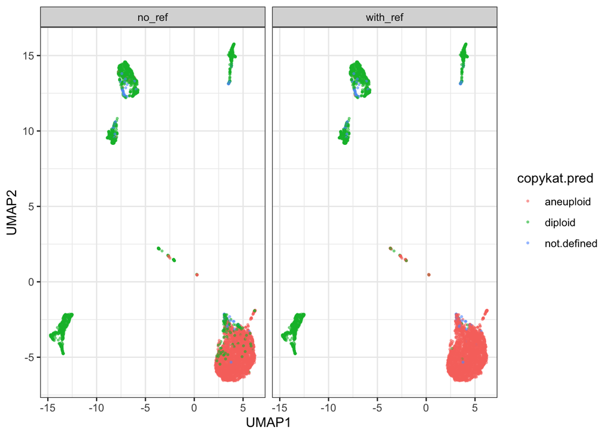

```r
ggplot(cnv_df, aes(x = UMAP1, y = UMAP2, color = copykat.pred)) +
  geom_point(alpha = 0.5, size = 0.5) +
  theme_bw() +
  facet_wrap(vars(reference_used))
```

### Confusion Matrix

Below we directly compare the annotations obtained using manual classification of tumor and normal cells to annotating cells with `CopyKAT`. To do this, we will calculate the confusion matrix using `caret::confusionMatrix()`.

```r
caret_df <- cnv_df |>
  dplyr::filter(copykat.pred != "not.defined") |>
  dplyr::mutate(copykat = ifelse(
    # use str_detect for test data
    copykat.pred == "diploid", "Normal", "Tumor"
  )) |>
  # make tumor the positive class
  dplyr::mutate(
    copykat = forcats::fct_relevel(copykat, "Tumor"),
    marker_gene_classification = forcats::fct_relevel(marker_gene_classification, "Tumor")
  ) |>
  split(cnv_df$reference_used)
caret_df |>
  purrr::imap(\(df, ref_type){
    glue::glue("\n\n================== {ref_type} ====================")
    caret::confusionMatrix(
      table(
        df$marker_gene_classification,
        df$copykat)
    )
  })
```

```
## $no_ref
## Confusion Matrix and Statistics
##
##
##          Tumor Normal
##   Tumor   2164    146
##   Normal   327   1566
##
##                Accuracy : 0.8875
##                  95% CI : (0.8775, 0.8969)
##     No Information Rate : 0.5927
##     P-Value [Acc > NIR] : < 2.2e-16
##
##                   Kappa : 0.7707
##
##  Mcnemar's Test P-Value : < 2.2e-16
##
##             Sensitivity : 0.8687
##             Specificity : 0.9147
##          Pos Pred Value : 0.9368
##          Neg Pred Value : 0.8273
##              Prevalence : 0.5927
##          Detection Rate : 0.5149
##    Detection Prevalence : 0.5496
##       Balanced Accuracy : 0.8917
##
##        'Positive' Class : Tumor
##
##
## $with_ref
## Confusion Matrix and Statistics
##
##
##          Tumor Normal
##   Tumor   2286     24
##   Normal   421   1472
##
##                Accuracy : 0.8941
##                  95% CI : (0.8844, 0.9033)
##     No Information Rate : 0.6441
##     P-Value [Acc > NIR] : < 2.2e-16
##
##                   Kappa : 0.782
##
##  Mcnemar's Test P-Value : < 2.2e-16
##
##             Sensitivity : 0.8445
##             Specificity : 0.9840
##          Pos Pred Value : 0.9896
##          Neg Pred Value : 0.7776
##              Prevalence : 0.6441
##          Detection Rate : 0.5439
##    Detection Prevalence : 0.5496
##       Balanced Accuracy : 0.9142
##
##        'Positive' Class : Tumor
##
```

We can also calculate the Jaccard similarity index to visualize the amount of cells that have overlapping annotations. Given the confusion matrix, I would expect to see good agreement between marker gene and `CopyKAT` annotations.

```r
# calculate Jaccard similarity index for each reference type
ref_types <- c("no_ref", "with_ref")
jaccard_matrices <- ref_types |>
  purrr::map(\(ref_type) {
    jaccard_df <- cnv_df |>
      dplyr::filter(reference_used == ref_type)

    make_jaccard_matrix(
      cnv_df,
      "marker_gene_classification",
      "copykat.pred"
    )
  }) |>
  purrr::set_names(ref_types)
```

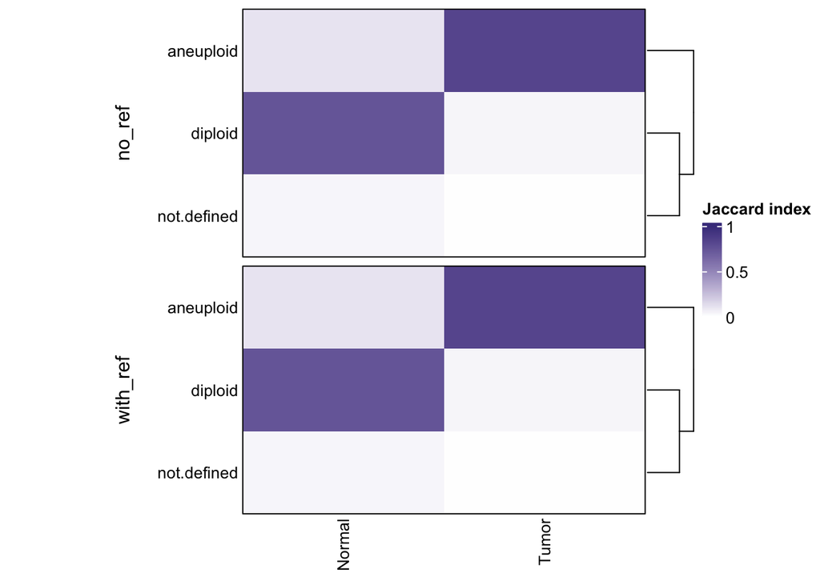

```r
# Set heatmap padding option
heatmap_padding <- 0.2
ComplexHeatmap::ht_opt(TITLE_PADDING = grid::unit(heatmap_padding, "in"))

# heatmaps comparing tumor/normal annotations manually vs. copyKAT
heatmap <- jaccard_matrices |>
  purrr::imap(
    \(jaccard_mtx, ref_type) {
      ComplexHeatmap::Heatmap(
        t(jaccard_mtx), # transpose because matrix rows are in common & we want a vertical arrangement
        col = circlize::colorRamp2(c(0, 1), colors = c("white", "darkslateblue")),
        border = TRUE,
        ## Row parameters
        cluster_rows = TRUE,
        row_title = ref_type,
        row_title_gp = grid::gpar(fontsize = 12),
        row_title_side = "left",
        row_names_side = "left",
        row_dend_side = "right",
        row_names_gp = grid::gpar(fontsize = 10),
        ## Column parameters
        cluster_columns = FALSE,
        column_title = "",
        column_title_gp = grid::gpar(fontsize = 12),
        column_names_side = "bottom",
        column_names_gp = grid::gpar(fontsize = 10),
        column_names_rot = 90,
        ## Legend parameters
        heatmap_legend_param = list(
          title = "Jaccard index",
          direction = "vertical",
          legend_width = unit(1.5, "in")
        ),
        show_heatmap_legend = ref_type == "no_ref",
      )
    }) |>
  # concatenate vertically into HeatmapList object
  purrr::reduce(ComplexHeatmap::`%v%`) |>
  ComplexHeatmap::draw(
    heatmap_legend_side = "right",
    # add a margin to the heatmap so labels don't get cut off
    padding = unit(c(2, 20, 2, 2), "mm")
  )
```

As expected, it looks like cells classified as tumor cells using marker gene annotation are classified as `aneuploid` with `CopyKAT`.

### Compare CopyKAT to SingleR and CellAssign

Lastly, we will compare the annotations from `CopyKAT` to those obtained using `SingleR` and `CellAssign` by calculating the Jaccard similarity index. For this comparison we will use just the annotations from `CopyKAT` with no reference.

```r
celltype_columns <- c(
  "singler_celltype_annotation",
  "cellassign_celltype_annotation"
)

# filter to only get annotations from no ref
no_ref_only <- cnv_df |>
  dplyr::filter(reference_used == "no_ref")

# create jaccard matrices for SingleR and CellAssign compared to aneuploid/diploid
jaccard_matrices <- celltype_columns |>
  purrr::map(\(name) {
    make_jaccard_matrix(
      no_ref_only,
      "copykat.pred",
      name
    )
  }) |>
  purrr::set_names("SingleR", "CellAssign")
```

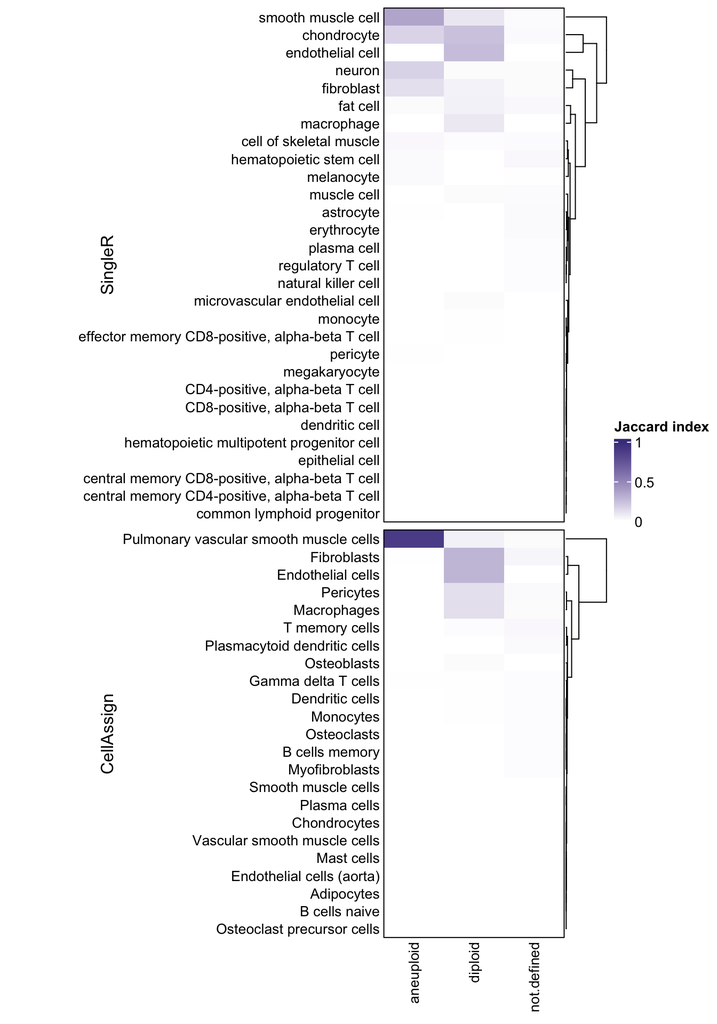

```r
# Set heatmap padding option
heatmap_padding <- 0.2
ComplexHeatmap::ht_opt(TITLE_PADDING = grid::unit(heatmap_padding, "in"))

# list of heatmaps looking at SingleR/ CellAssign vs tumor/normal
heatmap <- jaccard_matrices |>
  purrr::imap(
    \(celltype_mat, celltype_method) {
      ComplexHeatmap::Heatmap(
        t(celltype_mat), # transpose because matrix rows are in common & we want a vertical arrangement
        col = circlize::colorRamp2(c(0, 1), colors = c("white", "darkslateblue")),
        border = TRUE,
        ## Row parameters
        cluster_rows = TRUE,
        row_title = celltype_method,
        row_title_gp = grid::gpar(fontsize = 12),
        row_title_side = "left",
        row_names_side = "left",
        row_dend_side = "right",
        row_names_gp = grid::gpar(fontsize = 10),
        ## Column parameters
        cluster_columns = FALSE,
        column_title = "",
        column_title_gp = grid::gpar(fontsize = 12),
        column_names_side = "bottom",
        column_names_gp = grid::gpar(fontsize = 10),
        column_names_rot = 90,
        ## Legend parameters
        heatmap_legend_param = list(
          title = "Jaccard index",
          direction = "vertical",
          legend_width = unit(1.5, "in")
        ),
        show_heatmap_legend = celltype_method == "SingleR",
      )
    }) |>
  # concatenate vertically into HeatmapList object
  purrr::reduce(ComplexHeatmap::`%v%`) |>
  ComplexHeatmap::draw(
    heatmap_legend_side = "right",
    # add a margin to the heatmap so labels don't get cut off
    padding = unit(c(2, 20, 2, 2), "mm")
  )
```

We see that aneuploid cells are mostly muscle cells in both `CellAssign` and `SingleR`. In `SingleR` there are some other cell types that were assigned that have a few anueploid cells (chondrocytes, neurons, and fibroblasts).

For diploid cells, we see the most overlap with fibroblasts, endothelial cells, and macrophages. These are consistent with the cell types that we see normal cells line up with in `01-marker-gene-tumor-classification.Rmd`.

## Conclusions

- `CopyKAT` seems to do a good job in this Ewing sarcoma sample of identifying aneuploid and diploid cells.
- The annotations from `CopyKAT` mostly line up with annotations obtained using marker gene annotation.
- Using a reference of normal cells doesn’t change the overall results but does reduce the run time for `CopyKAT`.